# 1953年3月《商业与金融纪事报》专栏：我最看好的股票-西部保险证券

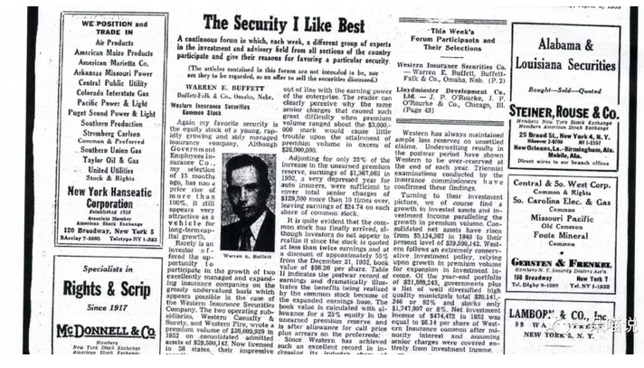

**我最看好的股票：西部保险证券(Western Insurance Securities)**

1953 年 3 月

*该专栏每周刊发系列文章，邀请全国各地的投资专家推荐并分析他们看好的一只股票。*

沃伦 E. 巴菲特

Buffett-Falk & Co., Omaha, Nebr.

**西部保险证券 (WesternInsurance Securities)**

我这次推荐的股票也是一家保险公司，它也是一家年轻的公司，而且发展速度快、管理有方。15 个月前，我推荐了政府雇员保险公司，现在股价已经涨了一倍多，从长期资本增值角度考虑，它还是不贵。

西部保险证券公司持有西部财险和担保公司92% 的股份，西部财险和担保公司持有西部火灾保险公司 99.95% 的股份。西部保险证券公司的其他资产很少，按净流动资产计算大概只有 180,000 美元。该公司的资本结构是 7,000 股面值为 100 美元，利率为 6% 的优先股，可以以 125 美元赎回；35,000 股 A类优先股，可以以 60 美元赎回，每股可定期获得 2.50 美元的股息，最多可获得 4 美元股息；还有 50,000 股普通股。A 类优先股目前合计拖欠股息 36.75 美元。

在雷•杜波克 (Ray DuBoc) 的领导下，公司拥有一流的管理层。从公司 1924 年创立以来，杜波克先生一直是公司的掌舵人，他在保险行业声誉卓著，为人正直而且能力出众。公司的中层管理人员同样是一流的。在公司成立初期，债券和优先股的成本远高于公司的盈利能力。保费规模在 3,000,000 美元时，债券和优先股的成本对公司是沉重的负担，但当公司的保费规模超过 26,000,000 美元时，这部分成本显然就不是问题了。

1952 年是汽车保险业务非常低迷的一年，该公司的盈利是 1,367,063 美元，可以覆盖 129,500 美元的债券和优先股成本的 10 倍多，扣除这部分费用后，普通股每股盈利仍然有 24.74 美元。

该公司总是保持充足的未决赔款准备金。从战后的记录来看，该公司每年年末的赔款准备金都比实际需要的金额高。保险监理机构对该公司进行的三年期检查得出了同样的结论。

在过去几年里，财产保险行业在汽车保险业务上遭受了巨大损失。1952 年末，这个趋势出现了强力反转。1951 年和 1952 年，保费大幅上调，今后续保时保费将大幅度提高，这对保险公司的业绩有极大的提升作用。预计 1953 年和 1954 年财产保险行业应当能取得良好盈利。

过去几年保险业不景气，西部保险证券公司都很赚钱，随着保费规模增加、投资资产增加以及保费上调，它的盈利能力将更上一层楼。保守估计，1954 年，该公司的满期保费规模将达到 30,000,000 美元。这个保费规模的正常盈利能力应该是平均每股 30 美元，其中包括投资收益在扣除所有债券和优先股成本后贡献的大约每股 8.40 美元。

坚守西部保险证券普通股的投资者有理由相信，随着公司的所有者权益显著增厚，普通股股东会得到实质的回报。我们要知道，在过去 12 年里，两家子公司将保费规模提升了 5.5 倍左右。相应地，公司需要将留存收益提升 3.5 倍，所以没能力派发股息。最近西部财险和担保公司提升了股息，今后应该能更及时地发放优先股的股息。如果公司能继续保持过去的高速增长，盈利能力将大幅增加，我认为很难保持过去那么快的增长速度。如果公司的保费规模增长放缓，公司有可能大幅提升派息。

西部保险证券公司所在的行业很稳定，它过去的成长能力和盈利能力都很突出，它现在的股价是 40 美元，投资这只股票有巨大的资本升值潜力。该股票在场外市场交易。